# 13_Object Detection using YOLO pretrained model

## YOLO (You Only Look Once) for Real-Time Object Detection

**YOLO (You Only Look Once)** is a deep learning–based object detection algorithm designed for **fast and real-time image processing**. Unlike traditional object detection methods that analyze different regions of an image separately, YOLO processes the **entire image in a single pass through a neural network**, making it extremely efficient.

In YOLO, the input image is **divided into a grid of cells** (for example, S × S). Each grid cell is responsible for detecting objects whose **center lies inside that cell**. For every grid cell, the network predicts:

- **Bounding box coordinates** (position and size of the object)
- **Confidence score** indicating the probability that an object exists in the predicted box
- **Class probabilities** representing the category of the detected object

By combining these predictions, YOLO can **detect multiple objects and classify them simultaneously** in a single forward pass of the network.

Because the entire image is processed at once, YOLO captures **global contextual information**, which helps reduce false detections compared to methods that examine small regions independently.

Due to its **high speed and efficiency**, YOLO is widely used in applications such as:

- Autonomous driving
- Video surveillance
- Robotics
- Real-time video analysis
- Smart cameras

## Is YOLO Better than CNN?

YOLO is not necessarily "better than CNN" because **YOLO itself is built using a Convolutional Neural Network (CNN)**. The two are not directly comparable. Instead:

- **CNN (Convolutional Neural Network)** is a general deep learning architecture used for image-related tasks such as classification, detection, and segmentation.
- **YOLO (You Only Look Once)** is a specific **object detection algorithm that uses CNN as its backbone**.

### Key Differences

| Feature | CNN (Basic) | YOLO |
| --- | --- | --- |
| Purpose | Mainly image classification | Object detection and classification |
| Output | Class label | Bounding boxes + object classes |
| Speed | Moderate | Very fast (real-time detection) |
| Detection ability | Cannot locate objects by default | Detects multiple objects in one image |

### Example

- A **basic CNN** might predict:  
  *"This image contains a dog."*
- **YOLO** can predict:  
  *"There is a dog at this location (bounding box) and a person at another location."*

### Why YOLO is Popular

YOLO is widely used because it can:

- Detect **multiple objects simultaneously**
- Process images **in real time**
- Perform detection using a **single forward pass of the CNN**

### Conclusion

- **CNN** is the **underlying neural network architecture**.
- **YOLO** is an **object detection framework built on CNN** that performs detection and classification in a single step.
- Each bounding box predicts objects inside and gives confidence score. It gives position and label.

Repositary link: https://github.com/AlexeyAB/darknet

### Downloading and cloning Darknet Repositary:

```python
!git clone https://github.com/AlexeyAB/darknet
```

```
Cloning into 'darknet'...
remote: Enumerating objects: 15941, done.
remote: Counting objects: 100% (32/32), done.
remote: Compressing objects: 100% (24/24), done.
remote: Total 15941 (delta 14), reused 9 (delta 8), pack-reused 15909 (from 2)
Receiving objects: 100% (15941/15941), 14.51 MiB | 7.05 MiB/s, done.
Resolving deltas: 100% (10720/10720), done.
```

```python
ls
```

```
darknet/  sample_data/
```

```python
cd darknet/
```

```
/content/darknet
```

```python
ls
```

```
3rdparty/               data/                   net_cam_v3.sh*
build/                  docker-compose.yml      net_cam_v4.sh*
CCM/                    Dockerfile.cpu          package.xml
cfg/                    Dockerfile.gpu          README.md
cmake/                  image_yolov3.sh*        scripts/
CMakeLists.txt          image_yolov4.sh*        src/
DarknetConfig.cmake.in  include/                vcpkg.json
darknet_images.py       json_mjpeg_streams.sh*  video_yolov3.sh*
darknet.py              LICENSE                 video_yolov4.sh*
darknet_video.py        Makefile
```

### Compile the library

```python
!make
```

[output not shown]

[output cut: 301 more lines]

[output not shown]

### Download the pre trained weights

```python
!wget https://github.com/AlexeyAB/darknet/releases/download/darknet_yolo_v3_optimal/yolov4.weights
```

```
--2026-03-14 08:13:47--  https://github.com/AlexeyAB/darknet/releases/download/darknet_yolo_v3_optimal/yolov4.weights
Resolving github.com (github.com)... 20.205.243.166
Connecting to github.com (github.com)|20.205.243.166|:443... connected.
HTTP request sent, awaiting response... 302 Found
Location: https://release-assets.githubusercontent.com/github-production-release-asset/75388965/ba4b6380-889c-11ea-9751-f994f5961796?sp=r&sv=2018-11-09&sr=b&spr=https&se=2026-03-14T08%3A58%3A57Z&rscd=attachment%3B+filename%3Dyolov4.weights&rsct=application%2Foctet-stream&skoid=96c2d410-5711-43a1-aed…
--2026-03-14 08:13:47--  https://release-assets.githubusercontent.com/github-production-release-asset/75388965/ba4b6380-889c-11ea-9751-f994f5961796?sp=r&sv=2018-11-09&sr=b&spr=https&se=2026-03-14T08%3A58%3A57Z&rscd=attachment%3B+filename%3Dyolov4.weights&rsct=application%2Foctet-stream&skoid=96c2d41…
Resolving release-assets.githubusercontent.com (release-assets.githubusercontent.com)... 185.199.108.133, 185.199.109.133, 185.199.110.133, ...
Connecting to release-assets.githubusercontent.com (release-assets.githubusercontent.com)|185.199.108.133|:443... connected.
HTTP request sent, awaiting response... 200 OK
Length: 257717640 (246M) [application/octet-stream]
Saving to: ‘yolov4.weights’

yolov4.weights      100%[===================>] 245.78M  35.3MB/s    in 6.9s

2026-03-14 08:13:54 (35.8 MB/s) - ‘yolov4.weights’ saved [257717640/257717640]
```

```python
ls
```

```
3rdparty/               data/                   obj/
backup/                 docker-compose.yml      package.xml
build/                  Dockerfile.cpu          README.md
CCM/                    Dockerfile.gpu          results/
cfg/                    image_yolov3.sh*        scripts/
cmake/                  image_yolov4.sh*        src/
CMakeLists.txt          include/                vcpkg.json
darknet*                json_mjpeg_streams.sh*  video_yolov3.sh*
DarknetConfig.cmake.in  LICENSE                 video_yolov4.sh*
darknet_images.py       Makefile                yolov4.weights
darknet.py              net_cam_v3.sh*
darknet_video.py        net_cam_v4.sh*
```

```python
!./darknet detect cfg/yolov4.cfg yolov4.weights data/person.jpg  # Giving input image as an command line arg.
```

```
 GPU isn't used
 OpenCV isn't used - data augmentation will be slow
mini_batch = 1, batch = 8, time_steps = 1, train = 0
   layer   filters  size/strd(dil)      input                output
   0 conv     32       3 x 3/ 1    608 x 608 x   3 ->  608 x 608 x  32 0.639 BF
   1 conv     64       3 x 3/ 2    608 x 608 x  32 ->  304 x 304 x  64 3.407 BF
   2 conv     64       1 x 1/ 1    304 x 304 x  64 ->  304 x 304 x  64 0.757 BF
   3 route  1 		                           ->  304 x 304 x  64
   4 conv     64       1 x 1/ 1    304 x 304 x  64 ->  304 x 304 x  64 0.757 BF
   5 conv     32       1 x 1/ 1    304 x 304 x  64 ->  304 x 304 x  32 0.379 BF
   6 conv     64       3 x 3/ 1    304 x 304 x  32 ->  304 x 304 x  64 3.407 BF
   7 Shortcut Layer: 4,  wt = 0, wn = 0, outputs: 304 x 304 x  64 0.006 BF
   8 conv     64       1 x 1/ 1    304 x 304 x  64 ->  304 x 304 x  64 0.757 BF
   9 route  8 2 	                           ->  304 x 304 x 128
  10 conv     64       1 x 1/ 1    304 x 304 x 128 ->  304 x 304 x  64 1.514 BF
```

[output cut: 170 more lines]

```python
import cv2
import matplotlib.pyplot as plt

image = cv2.imread('predictions.jpg')
```

```python
def show_detection(path):
  image = cv2.imread(path)
  plt.imshow(cv2.cvtColor(image, cv2.COLOR_BGR2RGB))
```

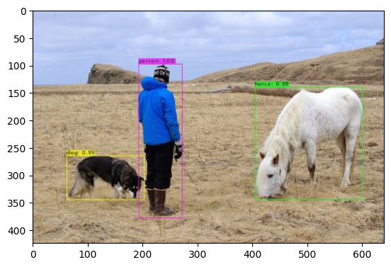

```python
show_detection('predictions.jpg')
```

### Darknet and GPU

```python
import tensorflow as tf
tf.test.gpu_device_name()
```

```
'/device:GPU:0'
```

```python
ls
```

```
3rdparty/               data/                   obj/
backup/                 docker-compose.yml      package.xml
build/                  Dockerfile.cpu          predictions.jpg
CCM/                    Dockerfile.gpu          README.md
cfg/                    image_yolov3.sh*        results/
cmake/                  image_yolov4.sh*        scripts/
CMakeLists.txt          include/                src/
darknet*                json_mjpeg_streams.sh*  vcpkg.json
DarknetConfig.cmake.in  LICENSE                 video_yolov3.sh*
darknet_images.py       Makefile                video_yolov4.sh*
darknet.py              net_cam_v3.sh*          yolov4.weights
darknet_video.py        net_cam_v4.sh*
```

| Line | Purpose |
| --- | --- |
| `OPENCV=1` | Enables OpenCV for image/video processing |
| `GPU=1` | Enables GPU acceleration |
| `CUDNN=1` | Enables NVIDIA cuDNN for faster deep learning |

```python
# Enable OpenCV
!sed -i 's/OPENCV=0/OPENCV=1/' Makefile

# Enable GPU
!sed -i 's/GPU=0/GPU=1/' Makefile

# Enable cuDNN
!sed -i 's/CUDNN=0/CUDNN=1/' Makefile
```

```python
#!make
```

```python
!./darknet detect cfg/yolov4.cfg yolov4.weights data/horses.jpg
```

```
 GPU isn't used
 OpenCV isn't used - data augmentation will be slow
mini_batch = 1, batch = 8, time_steps = 1, train = 0
   layer   filters  size/strd(dil)      input                output
   0 conv     32       3 x 3/ 1    608 x 608 x   3 ->  608 x 608 x  32 0.639 BF
   1 conv     64       3 x 3/ 2    608 x 608 x  32 ->  304 x 304 x  64 3.407 BF
   2 conv     64       1 x 1/ 1    304 x 304 x  64 ->  304 x 304 x  64 0.757 BF
   3 route  1 		                           ->  304 x 304 x  64
   4 conv     64       1 x 1/ 1    304 x 304 x  64 ->  304 x 304 x  64 0.757 BF
   5 conv     32       1 x 1/ 1    304 x 304 x  64 ->  304 x 304 x  32 0.379 BF
   6 conv     64       3 x 3/ 1    304 x 304 x  32 ->  304 x 304 x  64 3.407 BF
   7 Shortcut Layer: 4,  wt = 0, wn = 0, outputs: 304 x 304 x  64 0.006 BF
   8 conv     64       1 x 1/ 1    304 x 304 x  64 ->  304 x 304 x  64 0.757 BF
   9 route  8 2 	                           ->  304 x 304 x 128
  10 conv     64       1 x 1/ 1    304 x 304 x 128 ->  304 x 304 x  64 1.514 BF
```

[output cut: 172 more lines]

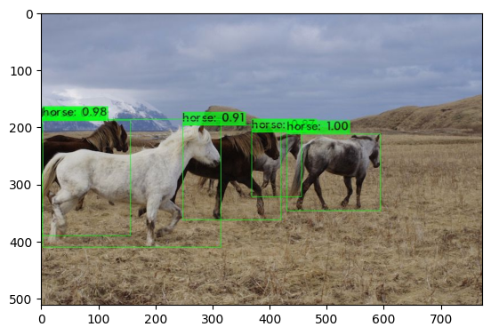

```python
show_detection('predictions.jpg')
```

```python
!./darknet detect cfg/yolov4.cfg yolov4.weights data/horses.jpg -thresh 0.9
```

```
 GPU isn't used
 OpenCV isn't used - data augmentation will be slow
mini_batch = 1, batch = 8, time_steps = 1, train = 0
   layer   filters  size/strd(dil)      input                output
   0 conv     32       3 x 3/ 1    608 x 608 x   3 ->  608 x 608 x  32 0.639 BF
   1 conv     64       3 x 3/ 2    608 x 608 x  32 ->  304 x 304 x  64 3.407 BF
   2 conv     64       1 x 1/ 1    304 x 304 x  64 ->  304 x 304 x  64 0.757 BF
   3 route  1 		                           ->  304 x 304 x  64
   4 conv     64       1 x 1/ 1    304 x 304 x  64 ->  304 x 304 x  64 0.757 BF
   5 conv     32       1 x 1/ 1    304 x 304 x  64 ->  304 x 304 x  32 0.379 BF
   6 conv     64       3 x 3/ 1    304 x 304 x  32 ->  304 x 304 x  64 3.407 BF
   7 Shortcut Layer: 4,  wt = 0, wn = 0, outputs: 304 x 304 x  64 0.006 BF
   8 conv     64       1 x 1/ 1    304 x 304 x  64 ->  304 x 304 x  64 0.757 BF
   9 route  8 2 	                           ->  304 x 304 x 128
  10 conv     64       1 x 1/ 1    304 x 304 x 128 ->  304 x 304 x  64 1.514 BF
```

[output cut: 170 more lines]

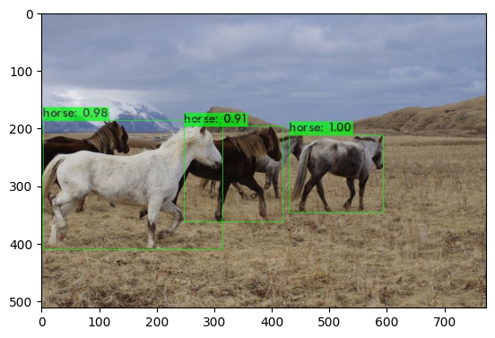

```python
show_detection('predictions.jpg')
```

```python
def show_detection(path):
  image = cv2.imread(path)
  plt.imshow(cv2.cvtColor(image, cv2.COLOR_BGR2RGB))
  plt.savefig('/content/drive/MyDrive/MCV_Continuatin_inGoogle_Colab/13_YOLO/output.jpg')
```

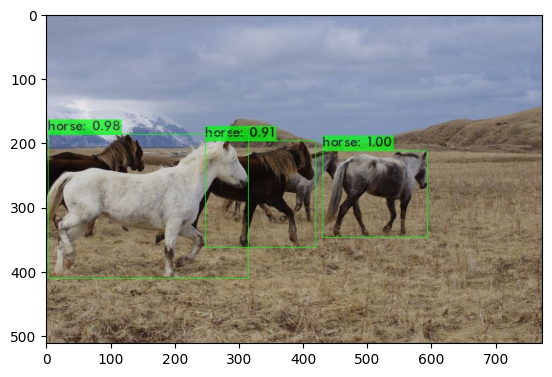

```python
show_detection('predictions.jpg')
```